# HDAT9600 Survival Analysis Modelling Assignment

Submission deadline - see course outline

## Instructions

This file is the R Markdown document in which you need to complete your HDAT9600 Survival Modelling assignment. This assignment is assessed and will count for 25% of the total course marks.

You should now complete the tasks described below, in the spaces provided. Don’t hesitate to ask the course instructor for help (use OpenLearning environment to do that) — but remember that these are **individual** assignments and thus what you submit should be your own work, and you need to both understand and be able to explain what you did in your solutions. The course convenor is happy to point you in the right direction and to make suggestions, but they won’t, of course, complete your assignments for you!

Each task below attracts the indicated number of marks (out of a total of 25 marks).

## Introduction

For the Survival Modelling assignment, we are going to analyse colon cancer survival data, available as a built-in dataset in the *survival* package. These data include information from a clinical trial on the effectiveness of two different types of chemotherapy (levamisole and levamisole+5-fluorouracil) compared to controls (i.e. no chemotherapy treatment) on survival from stage B/C colon cancer. There are two rows per person in the dataset, one for cancer recurrence and one for death, indicated by the event type (`etype`) variable (`etype==1` corresponds to recurrence and `etype==2` to death). In the tasks below, you will focus on analysing death as an outcome.

As the *survival* package is one of the core R packages, you don’t need to separately install it. To get started, you just need to load it into the workspace in R:

```r
library(survival)
```

We are then going to select a subset of the data. We will subset the dataset to only include deaths (not recurrence). We will also focus on just five of the potential predictors: `age` , `sex` , `rx` , `extent` , `node4` as below:

```r
#Choose just deaths and only the specified predictors
colondeath <- colon[colon$etype==2,
                   c("id","time","status","rx","age","sex","extent","node4")]
```

These selected variables are described in the package vignette as:

- `id`: id
- `time`: days until event or censoring
- `status`: censoring status
- `rx`: Treatment: Obs(ervation), Lev(amisole), Lev(amisole)+5-FU
- `sex`: (1=male, 0=female)
- `age`: in years
- `extent`: Extent of local spread (1=submucosa, 2=muscle, 3=serosa, 4=contiguous structures)
- `node4`: more than 4 positive lymph nodes (1=yes, 0=no)

Familiarise yourself with this dataset and complete the following tasks by writing R code and commentary text where appropriate. All quantitative results must be generated by R code which you have included in this file. Results calculated by other means or by code not included in this file will not receive any marks.

## Task 1 (3 marks)

(EDA: 3 marks)

Conduct a brief EDA making sure you address the following points:

- Describe the dataset in terms of number of people, and number/type of variables (0.5 marks)
- What was the median follow-up time until death? (0.5 marks)
- Briefly describe the frequency distributions for the variables - include frequencies and proportions for the categorical variables, and median and interquartile range (i.e. first quartile – third quartile) for any continuous variables. (1 mark) Is there a relationship between the predictors and the proportion surviving? (1 mark)

```r
# Look at the structure and summary for variables
str(colondeath)
```

```
## 'data.frame':    929 obs. of  8 variables:
##  $ id    : num  1 2 3 4 5 6 7 8 9 10 ...
##  $ time  : num  1521 3087 963 293 659 ...
##  $ status: num  1 0 1 1 1 1 1 0 0 0 ...
##  $ rx    : Factor w/ 3 levels "Obs","Lev","Lev+5FU": 3 3 1 3 1 3 2 1 2 3 ...
##  $ age   : num  43 63 71 66 69 57 77 54 46 68 ...
##  $ sex   : num  1 1 0 0 1 0 1 1 1 0 ...
##  $ extent: num  3 3 2 3 3 3 3 3 3 3 ...
##  $ node4 : num  1 0 1 1 1 1 1 0 0 0 ...
```

```r
summary(colondeath)
```

```
##        id           time          status             rx           age
##  Min.   :  1   Min.   :  23   Min.   :0.0000   Obs    :315   Min.   :18.00
##  1st Qu.:233   1st Qu.: 806   1st Qu.:0.0000   Lev    :310   1st Qu.:53.00
##  Median :465   Median :1976   Median :0.0000   Lev+5FU:304   Median :61.00
##  Mean   :465   Mean   :1670   Mean   :0.4865                 Mean   :59.75
##  3rd Qu.:697   3rd Qu.:2364   3rd Qu.:1.0000                 3rd Qu.:69.00
##  Max.   :929   Max.   :3329   Max.   :1.0000                 Max.   :85.00
##       sex            extent          node4
##  Min.   :0.000   Min.   :1.000   Min.   :0.0000
##  1st Qu.:0.000   1st Qu.:3.000   1st Qu.:0.0000
##  Median :1.000   Median :3.000   Median :0.0000
##  Mean   :0.521   Mean   :2.887   Mean   :0.2745
##  3rd Qu.:1.000   3rd Qu.:3.000   3rd Qu.:1.0000
##  Max.   :1.000   Max.   :4.000   Max.   :1.0000
```

```r
#Look at the status variable which describes deaths (1) and censoring (0)
table(colondeath$status)
```

```
##
##   0   1
## 477 452
```

```r
round(prop.table(table(colondeath$status)), digits=3)
```

```
##
##     0     1
## 0.513 0.487
```

* 49% died and 51% censored before death

```r
#Categorical predictors
#Convert rx sex, extent and node4 to factors
colondeath$rxf <- factor(colondeath$rx)
colondeath$sexf <- factor(colondeath$sex, labels=c("female","male"))
colondeath$extentf <- factor(colondeath$extent, labels=c("1.submucosa", "2.muscle", "3.serosa", "4.contiguous structures"))
colondeath$node4f <- factor(colondeath$node4, labels= c("no", "yes"))

#Assess frequencies and proportions for categorical predictor variables
table(colondeath$rxf)
```

```
##
##     Obs     Lev Lev+5FU
##     315     310     304
```

```r
round(prop.table(table(colondeath$rxf)), digits=3)
```

```
##
##     Obs     Lev Lev+5FU
##   0.339   0.334   0.327
```

```r
table(colondeath$sexf)
```

```
##
## female   male
##    445    484
```

```r
round(prop.table(table(colondeath$sexf)), digits=3)
```

```
##
## female   male
##  0.479  0.521
```

```r
table(colondeath$extentf)
```

```
##
##             1.submucosa                2.muscle                3.serosa
##                      21                     106                     759
## 4.contiguous structures
##                      43
```

```r
round(prop.table(table(colondeath$extentf)), digits=3)
```

```
##
##             1.submucosa                2.muscle                3.serosa
##                   0.023                   0.114                   0.817
## 4.contiguous structures
##                   0.046
```

```r
table(colondeath$node4f)
```

```
##
##  no yes
## 674 255
```

```r
round(prop.table(table(colondeath$node4f)), digits=3)
```

```
##
##    no   yes
## 0.726 0.274
```

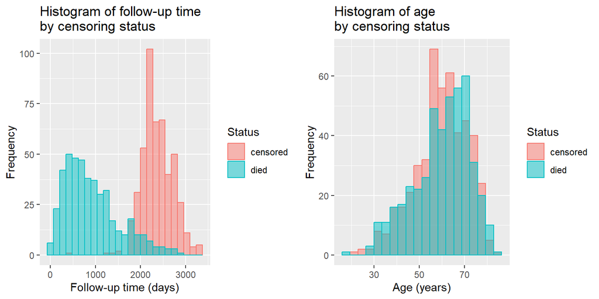

```r
#Plot histograms for the two continuous variables time and age

# Histogram of follow-up time by status in ggplot2
library(ggplot2)
p1 <- ggplot(colondeath, aes(x = time, fill = factor(status),colour = factor(status))) +
  geom_histogram(alpha=0.5, position='identity', bins=25)+
  xlab("Follow-up time (days)")+
  ylab("Frequency")+
  scale_color_discrete(name="Status", labels=c('censored', 'died'))+
  scale_fill_discrete(name="Status",labels=c('censored', 'died'))+
  ggtitle("Histogram of follow-up time \nby censoring status")
# Histogram of age by status
p2 <- ggplot(colondeath, aes(x = age, fill = factor(status),colour = factor(status))) +
  geom_histogram(alpha=0.5, position='identity', bins=20)+
  xlab("Age (years)")+
  ylab("Frequency")+
  scale_color_discrete(name="Status", labels=c('censored', 'died'))+
  scale_fill_discrete(name="Status",labels=c('censored', 'died'))+
  ggtitle("Histogram of age \nby censoring status")
library(gridExtra)
grid.arrange(p1,p2, nrow=1)
```

```r
#Calculate median and IQR for time overall and by censoring status
summary(colondeath$time)
```

```
##    Min. 1st Qu.  Median    Mean 3rd Qu.    Max.
##      23     806    1976    1670    2364    3329
```

```r
summary(colondeath$time[colondeath$status==1])
```

```
##    Min. 1st Qu.  Median    Mean 3rd Qu.    Max.
##    23.0   461.5   774.5   927.4  1247.5  2910.0
```

```r
summary(colondeath$time[colondeath$status==0])
```

```
##    Min. 1st Qu.  Median    Mean 3rd Qu.    Max.
##     453    2154    2331    2374    2598    3329
```

```r
#Calculate median and IQR for age overall and by censoring status
summary(colondeath$age)
```

```
##    Min. 1st Qu.  Median    Mean 3rd Qu.    Max.
##   18.00   53.00   61.00   59.75   69.00   85.00
```

```r
summary(colondeath$age[colondeath$status==1])
```

```
##    Min. 1st Qu.  Median    Mean 3rd Qu.    Max.
##    18.0    53.0    62.0    59.9    69.0    85.0
```

```r
summary(colondeath$age[colondeath$status==0])
```

```
##    Min. 1st Qu.  Median    Mean 3rd Qu.    Max.
##   22.00   53.00   60.00   59.61   68.00   83.00
```

```r
round(prop.table(table(colondeath$rxf, colondeath$status),1), digits=3)
```

```
##
##               0     1
##   Obs     0.467 0.533
##   Lev     0.481 0.519
##   Lev+5FU 0.595 0.405
```

```r
round(prop.table(table(colondeath$sexf, colondeath$status),1), digits=3)
```

```
##
##              0     1
##   female 0.517 0.483
##   male   0.510 0.490
```

```r
round(prop.table(table(colondeath$extentf, colondeath$status),1), digits=3)
```

```
##
##                               0     1
##   1.submucosa             0.810 0.190
##   2.muscle                0.660 0.340
##   3.serosa                0.495 0.505
##   4.contiguous structures 0.326 0.674
```

```r
round(prop.table(table(colondeath$node4f, colondeath$status),1), digits=3)
```

```
##
##           0     1
##   no  0.598 0.402
##   yes 0.290 0.710
```

- *The dataset contains 929 observations.*
- *There are 8 variables including: a numeric id variable `id`; `time`, also numeric which measures follow-up time in days; a numeric censoring variable (`status`); and 5 predictor variables. Of the predictors `age` is continuous and `sex`, treatment (`rx`), `extent` and `node4` are all categorical.*
- *Overall 452 people (49%) died during follow up and the median follow-up time until death was 775 days [IQR: 462-1248].*
- *The median age of the cohort was 61 years [IQR: 53-69] with a very slightly negatively skewed distribution. Age did not appear to be related to proportion surviving.*
- *There were 445 females (48%) and 484 males (52%). Sex did not appear to be related to proportion surviving.*
- *There were approximately even numbers of people across the three treatment groups. Treatment did appear related to proportion surviving with survival lowest in the observation group (47%) and highest in the Lev+5FU group (60%)*
- *Most people’s cancers had spread to the serosa (82%) and survival appeared related to the extent of spread, ranging from 81% surviving if spread was to the submucosa down to 33% if spread was to contiguous structures.*
- *27% had four or more positive lymph nodes and this nodal involvement was related to a lower proportion surviving (No: 60%, Yes:29%).*

## Task 2 (2 marks)

(EDA/Presentation: 2 marks)

#### Task 2.a

Plot the overall Kaplan-Meier survival curve for the `colondeath` data. (1 mark)

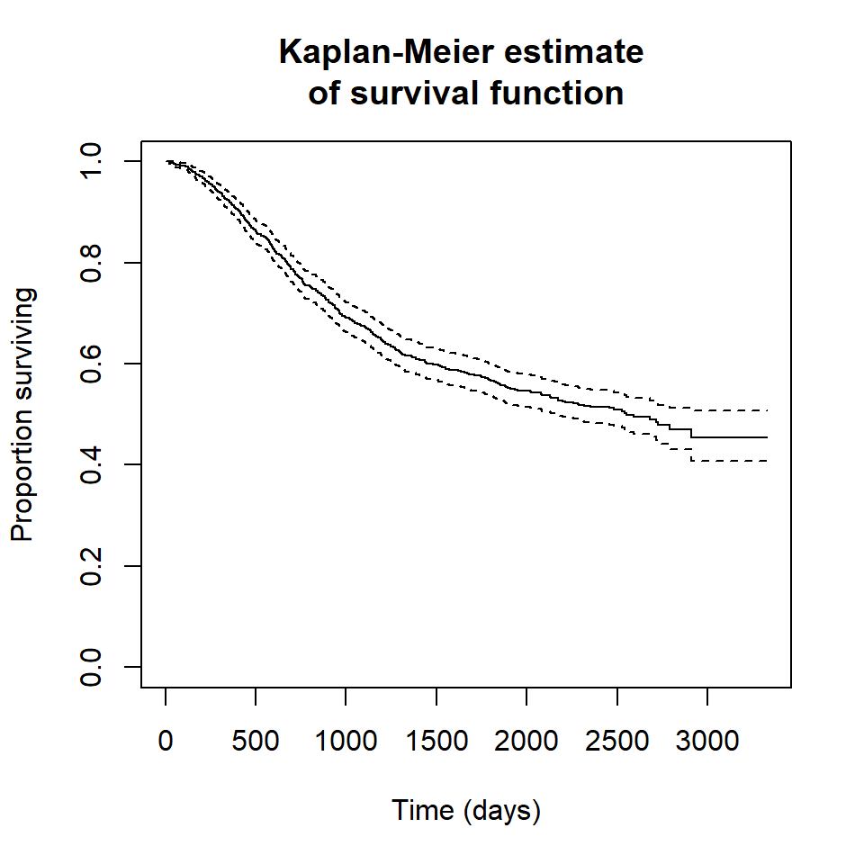

```r
# fit a survival object with no predictors
fit <- survfit(Surv(time,status)~1, data=colondeath)
# plot the KM curve
plot(fit,  main = "Kaplan-Meier estimate \nof survival function", xlab = "Time (days)", ylab= "Proportion surviving")
```

#### Task 2.b

Plot the Nelson-Aalen cumulative hazard function for the `colondeath` data. (1 mark)

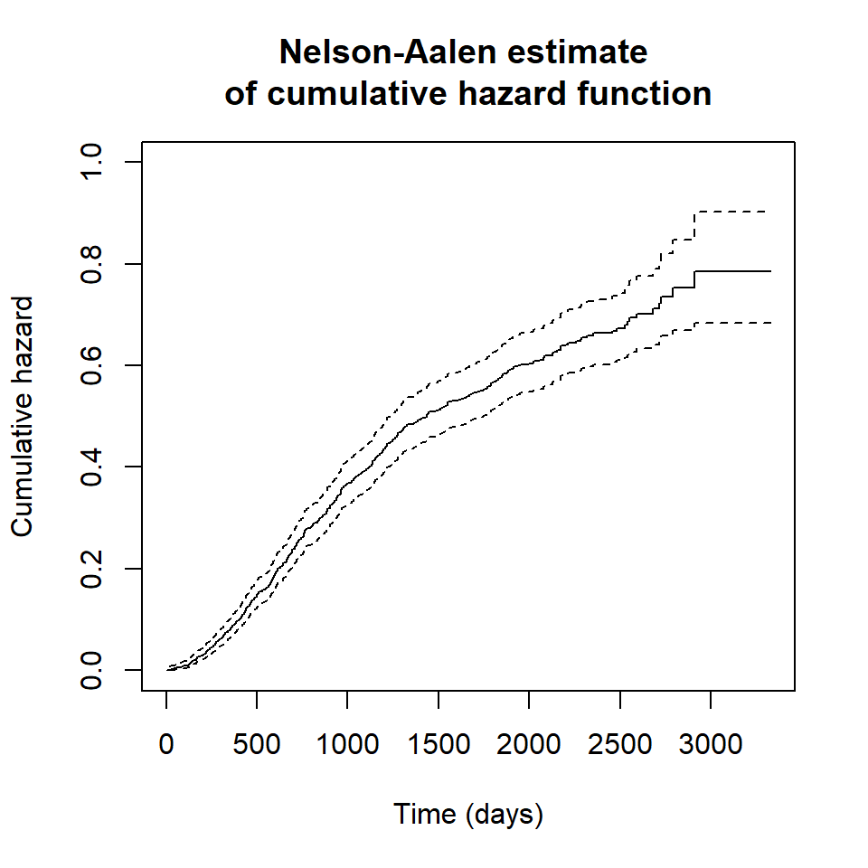

```r
# insert your R code (with comment lines if you wish) here
plot(fit, fun="cumhaz", main = "Nelson-Aalen estimate \nof cumulative hazard function", xlab = "Time (days)", ylab= "Cumulative hazard", ylim = c(0,1))
```

_*Marking note: 0.5 mark deduction if missing any key elements on plots such as axis labels or titles etc._

## Task 3 (4 marks)

(EDA/Modelling/Presentation: 3 marks; Interpretation: 1 mark)

#### Task 3.a

Plot the Kaplan-Meier survival curves, by group, for each of the categorical variables in the data. (1 mark)

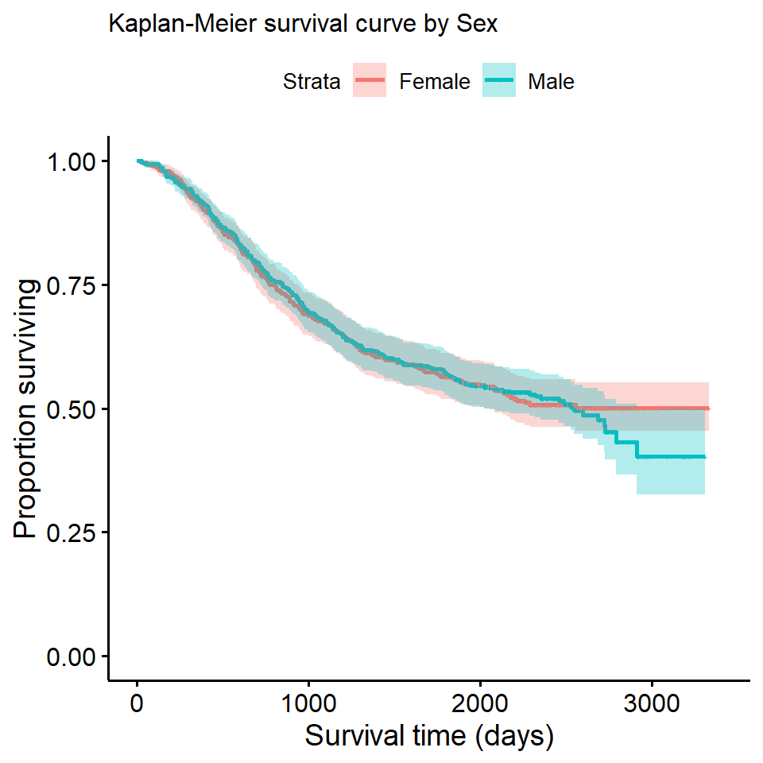

```r
# fit a series of models for each categorical predictor
fit.sex <- survfit(Surv(time,status)~sexf, data=colondeath)
fit.rx <- survfit(Surv(time,status)~rxf, data=colondeath)
fit.extent <- survfit(Surv(time,status)~extentf, data=colondeath)
fit.node <- survfit(Surv(time,status)~node4f, data=colondeath)
#plot the Kaplan-Meier curve with ggplot
library(ggplot2)
library(survminer)
 ggsurvplot(fit.sex, data=colondeath, conf.int = TRUE, xlim=c(0,3400), censor.size=1,
           legend.labs=c("Female","Male"), font.title=c(12))+
  xlab("Survival time (days)") +
  ylab("Proportion surviving")+
  ggtitle("Kaplan-Meier survival curve by Sex")
```

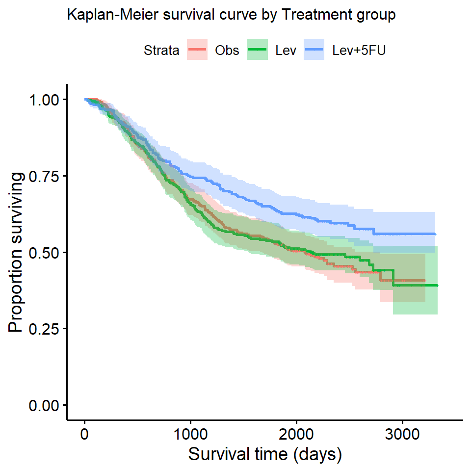

```r
ggsurvplot(fit.rx, data=colondeath, conf.int = TRUE, xlim=c(0,3400),  censor.size=1,
           legend.labs=c("Obs","Lev", "Lev+5FU"), font.title=c(12))+
  xlab("Survival time (days)") +
  ylab("Proportion surviving")+
  ggtitle("Kaplan-Meier survival curve by Treatment group")
```

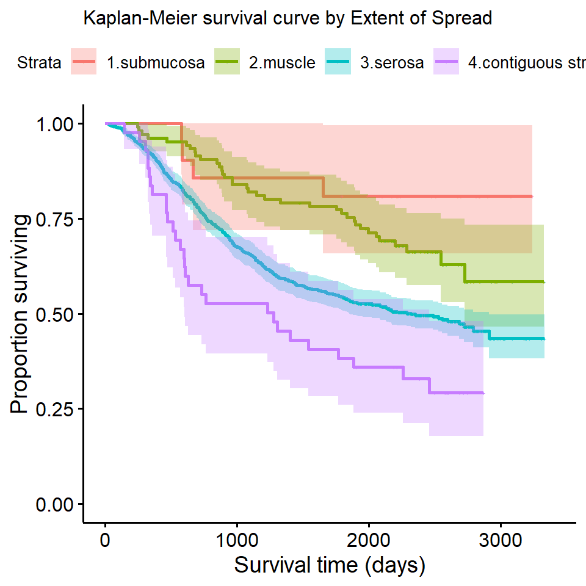

```r
ggsurvplot(fit.extent, data=colondeath, conf.int = TRUE, xlim=c(0,3400),  censor.size=1,
           legend.labs=c("1.submucosa","2.muscle", "3.serosa", "4.contiguous structures"), font.title=c(12))+
  xlab("Survival time (days)") +
  ylab("Proportion surviving")+
  ggtitle("Kaplan-Meier survival curve by Extent of Spread")
```

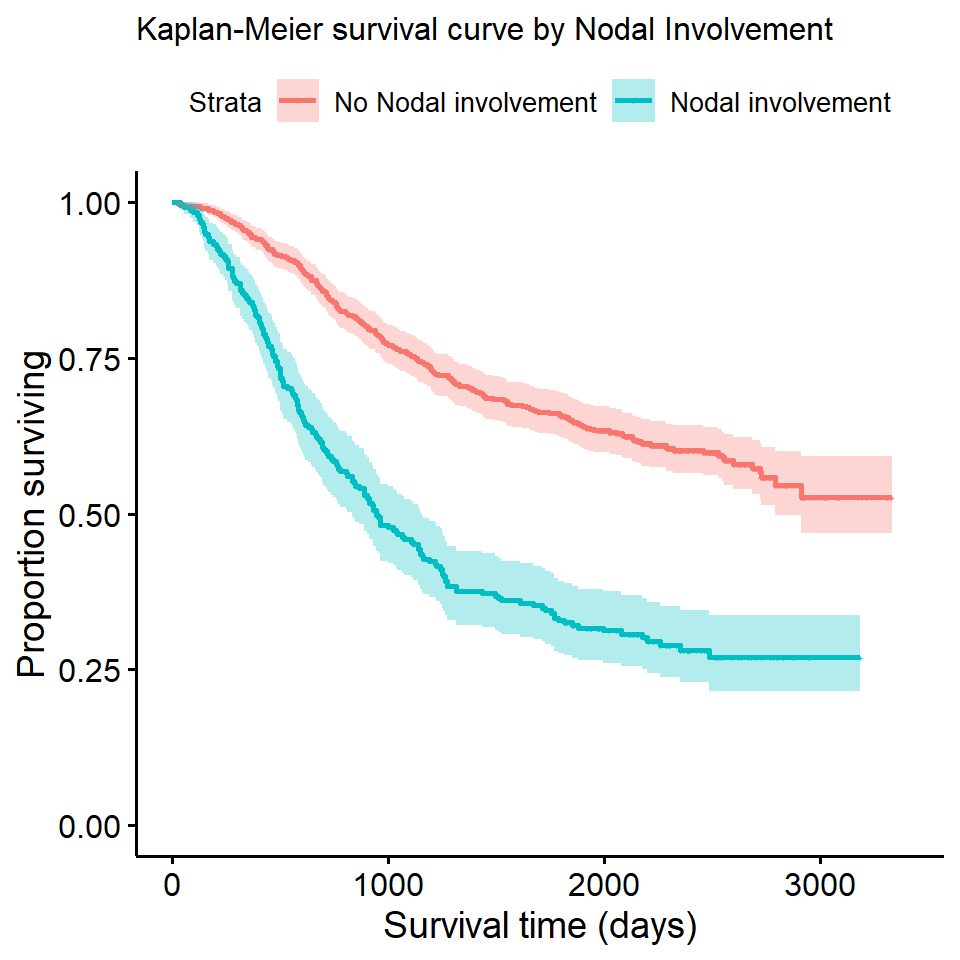

```r
ggsurvplot(fit.node, data=colondeath, conf.int = TRUE, xlim=c(0,3400),  censor.size=1,
           legend.labs=c("No Nodal involvement","Nodal involvement"), font.title=c(12))+
  xlab("Survival time (days)") +
  ylab("Proportion surviving")+
  ggtitle("Kaplan-Meier survival curve by Nodal Involvement")
```

#### Task 3.b

Report the number of deaths and the median survival times by categories for all categorical variables in the data (for example in the format of a table). (1 mark)

```r
# We can extract the number of deaths and median survival times from the fit summaries for each predictor
rbind(
summary(fit.rx)$table[,c('records','events','median','0.95LCL','0.95UCL')],
summary(fit.sex)$table[,c('records','events','median','0.95LCL','0.95UCL')],
summary(fit.extent)$table[,c('records','events','median','0.95LCL','0.95UCL')],
summary(fit.node)$table[,c('records','events','median','0.95LCL','0.95UCL')]
)
```

```
##                                 records events median 0.95LCL 0.95UCL
## rxf=Obs                             315    168   2083    1656    2789
## rxf=Lev                             310    161   2152    1540      NA
## rxf=Lev+5FU                         304    123     NA    2725      NA
## sexf=female                         445    215     NA    2077      NA
## sexf=male                           484    237   2542    2052    2910
## extentf=1.submucosa                  21      4     NA      NA      NA
## extentf=2.muscle                    106     36     NA    2725      NA
## extentf=3.serosa                    759    383   2318    1856    2910
## extentf=4.contiguous structures      43     29   1276     599    2458
## node4f=no                           674    271     NA    2789      NA
## node4f=yes                          255    181    944     833    1154
```

#### Task 3.c

Carry out the log-rank tests for differences in survival experience by the categorical variables and interpret the results. (1 mark modelling; 1 mark interpretation)

```r
# We can calculate the Log-Rank test using the survdiff function
survdiff(Surv(time,status)~sexf, data=colondeath)
```

```
## Call:
## survdiff(formula = Surv(time, status) ~ sexf, data = colondeath)
##
##               N Observed Expected (O-E)^2/E (O-E)^2/V
## sexf=female 445      215      217   0.01049    0.0202
## sexf=male   484      237      235   0.00965    0.0202
##
##  Chisq= 0  on 1 degrees of freedom, p= 0.9
```

```r
survdiff(Surv(time,status)~rxf, data=colondeath)
```

```
## Call:
## survdiff(formula = Surv(time, status) ~ rxf, data = colondeath)
##
##               N Observed Expected (O-E)^2/E (O-E)^2/V
## rxf=Obs     315      168      148      2.58      3.85
## rxf=Lev     310      161      146      1.52      2.25
## rxf=Lev+5FU 304      123      157      7.55     11.62
##
##  Chisq= 11.7  on 2 degrees of freedom, p= 0.003
```

```r
survdiff(Surv(time,status)~extentf, data=colondeath)
```

```
## Call:
## survdiff(formula = Surv(time, status) ~ extentf, data = colondeath)
##
##                                   N Observed Expected (O-E)^2/E (O-E)^2/V
## extentf=1.submucosa              21        4     12.8      6.06      6.25
## extentf=2.muscle                106       36     60.9     10.21     11.82
## extentf=3.serosa                759      383    361.7      1.26      6.29
## extentf=4.contiguous structures  43       29     16.6      9.34      9.71
##
##  Chisq= 26.9  on 3 degrees of freedom, p= 6e-06
```

```r
survdiff(Surv(time,status)~node4f, data=colondeath)
```

```
## Call:
## survdiff(formula = Surv(time, status) ~ node4f, data = colondeath)
##
##              N Observed Expected (O-E)^2/E (O-E)^2/V
## node4f=no  674      271    358.7      21.5       105
## node4f=yes 255      181     93.3      82.5       105
##
##  Chisq= 105  on 1 degrees of freedom, p= <2e-16
```

*There was no difference in survival by sex (Chisq= 0; p=0.9).*  
*The KM plot suggests that there may be a survival advantage for the Levamisole + 5FU group compared to the observation and Levamisole only groups. The Log-rank test shows there is a survival difference between the treatment groups (Chisq= 11.7; p=0.003).*  
*The KM plot suggests that there may be a decreasing survival rate with increasing degree of spread. The Log-rank test shows there is a survival difference between the four levels of extent of spread (Chisq= 26.9; p= <0.001).*  
*The KM plot suggests that having 4 or more nodes positive (compared to less nodes) was related to poorer survival and the Log-rank test shows this difference was significant (Chisq= 105, p= <0.001).*

## Task 4 (8 marks)

(Modelling: 4 marks; Interpretation: 4 marks)

#### Task 4.a

Fit univariable Cox models separately for all five predictor variables in the data. Interpret the results. (1 mark models; 1 mark interpretation)

```r
# insert your R code (with comment lines if you wish) here
cox.age <- coxph(Surv(time,status)~age, data=colondeath)
summary(cox.age)
```

```
## Call:
## coxph(formula = Surv(time, status) ~ age, data = colondeath)
##
##   n= 929, number of events= 452
##
##         coef exp(coef) se(coef)     z Pr(>|z|)
## age 0.001954  1.001956 0.004030 0.485    0.628
##
##     exp(coef) exp(-coef) lower .95 upper .95
## age     1.002      0.998    0.9941      1.01
##
## Concordance= 0.514  (se = 0.014 )
## Likelihood ratio test= 0.24  on 1 df,   p=0.6
## Wald test            = 0.24  on 1 df,   p=0.6
## Score (logrank) test = 0.24  on 1 df,   p=0.6
```

```r
cox.sex <- coxph(Surv(time,status)~sexf, data=colondeath)
summary(cox.sex)
```

```
## Call:
## coxph(formula = Surv(time, status) ~ sexf, data = colondeath)
##
##   n= 929, number of events= 452
##
##             coef exp(coef) se(coef)     z Pr(>|z|)
## sexfmale 0.01332   1.01341  0.09420 0.141    0.888
##
##          exp(coef) exp(-coef) lower .95 upper .95
## sexfmale     1.013     0.9868    0.8426     1.219
##
## Concordance= 0.497  (se = 0.012 )
## Likelihood ratio test= 0.02  on 1 df,   p=0.9
## Wald test            = 0.02  on 1 df,   p=0.9
## Score (logrank) test = 0.02  on 1 df,   p=0.9
```

```r
cox.rx <- coxph(Surv(time,status)~rxf, data=colondeath)
summary(cox.rx)
```

```
## Call:
## coxph(formula = Surv(time, status) ~ rxf, data = colondeath)
##
##   n= 929, number of events= 452
##
##                coef exp(coef) se(coef)      z Pr(>|z|)
## rxfLev     -0.02664   0.97371  0.11030 -0.241  0.80917
## rxfLev+5FU -0.37171   0.68955  0.11875 -3.130  0.00175 **
## ---
## Signif. codes:  0 '***' 0.001 '**' 0.01 '*' 0.05 '.' 0.1 ' ' 1
##
##            exp(coef) exp(-coef) lower .95 upper .95
## rxfLev        0.9737      1.027    0.7844    1.2087
## rxfLev+5FU    0.6896      1.450    0.5464    0.8703
##
## Concordance= 0.536  (se = 0.013 )
## Likelihood ratio test= 12.15  on 2 df,   p=0.002
## Wald test            = 11.56  on 2 df,   p=0.003
## Score (logrank) test = 11.68  on 2 df,   p=0.003
```

```r
cox.extent <- coxph(Surv(time,status)~extentf, data=colondeath)
summary(cox.extent)
```

```
## Call:
## coxph(formula = Surv(time, status) ~ extentf, data = colondeath)
##
##   n= 929, number of events= 452
##
##                                  coef exp(coef) se(coef)     z Pr(>|z|)
## extentf2.muscle                0.6391    1.8948   0.5272 1.212   0.2254
## extentf3.serosa                1.2240    3.4008   0.5028 2.435   0.0149 *
## extentf4.contiguous structures 1.7283    5.6313   0.5336 3.239   0.0012 **
## ---
## Signif. codes:  0 '***' 0.001 '**' 0.01 '*' 0.05 '.' 0.1 ' ' 1
##
##                                exp(coef) exp(-coef) lower .95 upper .95
## extentf2.muscle                    1.895     0.5278    0.6743     5.325
## extentf3.serosa                    3.401     0.2940    1.2695     9.110
## extentf4.contiguous structures     5.631     0.1776    1.9787    16.026
##
## Concordance= 0.552  (se = 0.009 )
## Likelihood ratio test= 29.21  on 3 df,   p=2e-06
## Wald test            = 25.35  on 3 df,   p=1e-05
## Score (logrank) test = 26.94  on 3 df,   p=6e-06
```

```r
cox.node <- coxph(Surv(time,status)~node4f, data=colondeath)
summary(cox.node)
```

```
## Call:
## coxph(formula = Surv(time, status) ~ node4f, data = colondeath)
##
##   n= 929, number of events= 452
##
##             coef exp(coef) se(coef)     z Pr(>|z|)
## node4fyes 0.9539    2.5960   0.0966 9.875   <2e-16 ***
## ---
## Signif. codes:  0 '***' 0.001 '**' 0.01 '*' 0.05 '.' 0.1 ' ' 1
##
##           exp(coef) exp(-coef) lower .95 upper .95
## node4fyes     2.596     0.3852     2.148     3.137
##
## Concordance= 0.606  (se = 0.011 )
## Likelihood ratio test= 88.95  on 1 df,   p=<2e-16
## Wald test            = 97.52  on 1 df,   p=<2e-16
## Score (logrank) test = 104.9  on 1 df,   p=<2e-16
```

*Age was not related to the hazard of death (HR: 1.00; 95%CI: 0.99-1.01).* *Sex was not related to the hazard of death (Male vs Female HR:1.01; 95%CI: 0.84-1.22).* *Compared to observation only, Levamisole + 5FU was associated with a 31% lower death rate (HR: 0.69; 95%CI: 0.55-0.87). Levamisole alone did not have a significantly different hazard of death compared to the observation group (HR:0.97; 95%CI: 0.78-1.21).* *Compared to spread confined to the submucosa, spread to contiguous structures was associated with an almost 6-fold increase in death rate (HR:5.63; 95%CI:1.98-16.03) and spread to the serosa was associated with a 3-fold increase (HR:3.40; 95%CI:1.27-9.11). There was no difference between the muscle and submucosa groups.* *Having four or more positive lymph nodes (compared to less) was associated with a 2.6-fold increase in hazard of death (HR: 2.60; 95%CI: 2.15-3.14).*

#### Task 4.b

Fit a full multivariable Cox model with all five predictor variables. Interpret the results. Are all the variables that were significant in the univariable models still significant in the multivariable model? (1 mark model; 1 mark interpretation)

```r
# Fit a full model
cox.full <- coxph(Surv(time,status)~age+sexf+rxf+extentf+node4f, data=colondeath)
summary(cox.full)
```

```
## Call:
## coxph(formula = Surv(time, status) ~ age + sexf + rxf + extentf +
##     node4f, data = colondeath)
##
##   n= 929, number of events= 452
##
##                                     coef exp(coef)  se(coef)      z Pr(>|z|)
## age                             0.006703  1.006725  0.004037  1.660  0.09683
## sexfmale                        0.031838  1.032350  0.094670  0.336  0.73664
## rxfLev                         -0.048086  0.953051  0.110569 -0.435  0.66363
## rxfLev+5FU                     -0.383574  0.681421  0.119038 -3.222  0.00127
## extentf2.muscle                 0.373771  1.453204  0.529115  0.706  0.47993
## extentf3.serosa                 0.900031  2.459681  0.505207  1.782  0.07483
## extentf4.contiguous structures  1.396210  4.039860  0.535221  2.609  0.00909
## node4fyes                       0.934915  2.546998  0.097713  9.568  < 2e-16
##
## age                            .
## sexfmale
## rxfLev
## rxfLev+5FU                     **
## extentf2.muscle
## extentf3.serosa                .
## extentf4.contiguous structures **
## node4fyes                      ***
## ---
## Signif. codes:  0 '***' 0.001 '**' 0.01 '*' 0.05 '.' 0.1 ' ' 1
##
##                                exp(coef) exp(-coef) lower .95 upper .95
## age                               1.0067     0.9933    0.9988    1.0147
## sexfmale                          1.0324     0.9687    0.8575    1.2428
## rxfLev                            0.9531     1.0493    0.7674    1.1837
## rxfLev+5FU                        0.6814     1.4675    0.5396    0.8605
## extentf2.muscle                   1.4532     0.6881    0.5152    4.0993
## extentf3.serosa                   2.4597     0.4066    0.9138    6.6208
## extentf4.contiguous structures    4.0399     0.2475    1.4151   11.5331
## node4fyes                         2.5470     0.3926    2.1031    3.0846
##
## Concordance= 0.659  (se = 0.013 )
## Likelihood ratio test= 125.4  on 8 df,   p=<2e-16
## Wald test            = 129.1  on 8 df,   p=<2e-16
## Score (logrank) test = 138.9  on 8 df,   p=<2e-16
```

```r
# check the significance of variables
drop1(cox.full, test="Chisq")
```

```
## Single term deletions
##
## Model:
## Surv(time, status) ~ age + sexf + rxf + extentf + node4f
##         Df    AIC    LRT  Pr(>Chi)
## <none>     5751.0
## age      1 5751.8  2.798  0.094374 .
## sexf     1 5749.1  0.113  0.736579
## rxf      2 5759.3 12.286  0.002149 **
## extentf  3 5766.5 21.482  8.36e-05 ***
## node4f   1 5833.1 84.101 < 2.2e-16 ***
## ---
## Signif. codes:  0 '***' 0.001 '**' 0.01 '*' 0.05 '.' 0.1 ' ' 1
```

*A full model was tested with age, sex, treatment, extent of spread and nodal involvement as predictors. The relationships between predictors and time to death remained very similar to the univariate relationships. After controlling for other variables, age and sex were not significantly related to the hazard of death (p=0.09 and p=0.74 respectively). There was a slight reduction in effect size for extent of spread resulting in only a significant difference between the highest (contiguous structures) versus lowest (submucosa) extent groups (Adjusted HR: 4.04; 95%CI: 1.42-11.53). The effect sizes were very similar for treatment and nodal involvement. Compared to observation, having had levamisole +FU was related to 32% reduction in hazard of death (Adjusted HR:0.68; 95%CI: 0.54-0.86) but there was no difference between Levamisole and observation. Having four or more positive lymph nodes (compared to less) was associated with a 2.5-fold increase in hazard of death (Adjusted HR: 2.55; 95%CI: 2.10-3.08).*

#### Task 4.c

Fit a reduced multivariable Cox model retaining only the variables that were significant in the full model (4b). What are the AICs for the full and reduced models (show how you calculated them) and how are they interpreted? (1 mark AICs; 1 mark interpretation)

```r
# run a reduced model
cox.red <- coxph(Surv(time,status)~rxf+extentf+node4f, data=colondeath)
summary(cox.red)
```

```
## Call:
## coxph(formula = Surv(time, status) ~ rxf + extentf + node4f,
##     data = colondeath)
##
##   n= 929, number of events= 452
##
##                                    coef exp(coef) se(coef)      z Pr(>|z|)
## rxfLev                         -0.04248   0.95841  0.11052 -0.384  0.70071
## rxfLev+5FU                     -0.37917   0.68443  0.11890 -3.189  0.00143 **
## extentf2.muscle                 0.41635   1.51642  0.52816  0.788  0.43051
## extentf3.serosa                 0.93099   2.53703  0.50453  1.845  0.06500 .
## extentf4.contiguous structures  1.41270   4.10702  0.53499  2.641  0.00828 **
## node4fyes                       0.91540   2.49779  0.09702  9.435  < 2e-16 ***
## ---
## Signif. codes:  0 '***' 0.001 '**' 0.01 '*' 0.05 '.' 0.1 ' ' 1
##
##                                exp(coef) exp(-coef) lower .95 upper .95
## rxfLev                            0.9584     1.0434    0.7718     1.190
## rxfLev+5FU                        0.6844     1.4611    0.5422     0.864
## extentf2.muscle                   1.5164     0.6594    0.5386     4.270
## extentf3.serosa                   2.5370     0.3942    0.9438     6.820
## extentf4.contiguous structures    4.1070     0.2435    1.4393    11.720
## node4fyes                         2.4978     0.4004    2.0652     3.021
##
## Concordance= 0.651  (se = 0.013 )
## Likelihood ratio test= 122.5  on 6 df,   p=<2e-16
## Wald test            = 126.1  on 6 df,   p=<2e-16
## Score (logrank) test = 135.8  on 6 df,   p=<2e-16
```

```r
# AIC function will extract the AIC. You could also calculate this manually
AIC(cox.red)
```

```
## [1] 5749.932
```

```r
AIC(cox.full)
```

```
## [1] 5751.025
```

*The AIC for the reduced model was 5750 and for the full model was 5751. These are very similar, but the slightly lower AIC for the reduced model suggests it is fitting the data better and as it is more parsimonious is likely to be the preferred model.*

#### Task 4.d

Compare the full and reduced models using the likelihood ratio test. Interpret the results. (1 mark modelling; 1 mark interpretation)

```r
# We can compare the two models using the anova() function
anova(cox.full, cox.red, test='LRT')
```

```
## Analysis of Deviance Table
##  Cox model: response is  Surv(time, status)
##  Model 1: ~ age + sexf + rxf + extentf + node4f
##  Model 2: ~ rxf + extentf + node4f
##    loglik  Chisq Df Pr(>|Chi|)
## 1 -2867.5
## 2 -2869.0 2.9064  2     0.2338
```

*The LRT shows no significant difference between the two models (Chisq=2.91; p=0.234). This suggests that the reduced model is fitting the data just as well as the full model.*